# Risk Management, class1

Omar Alfaro-Rivera

18/8/2020

# Future vs Historical Distribution

```r
library(quantmod)
library(moments)
options(getSymbols.warning4.0 = FALSE)


gold <-getSymbols("GOLDPMGBD228NLBM", src = "FRED", auto.assign = FALSE)
gold <- na.omit(gold)
gold <- gold["1979-12-31/2017-12-31"]
names(gold) <-"TR"
logret <- diff(log(gold$TR))[-1]
```

## Volatility clustering

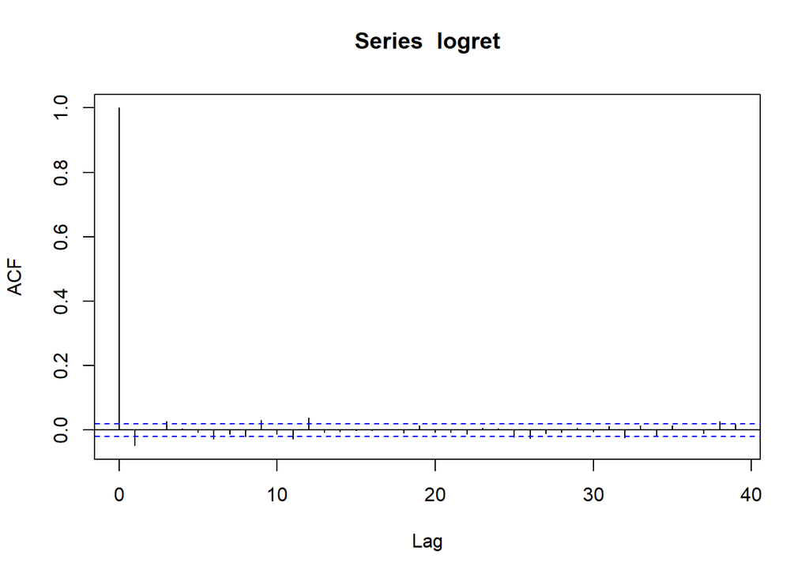

```r
acf(logret)
```

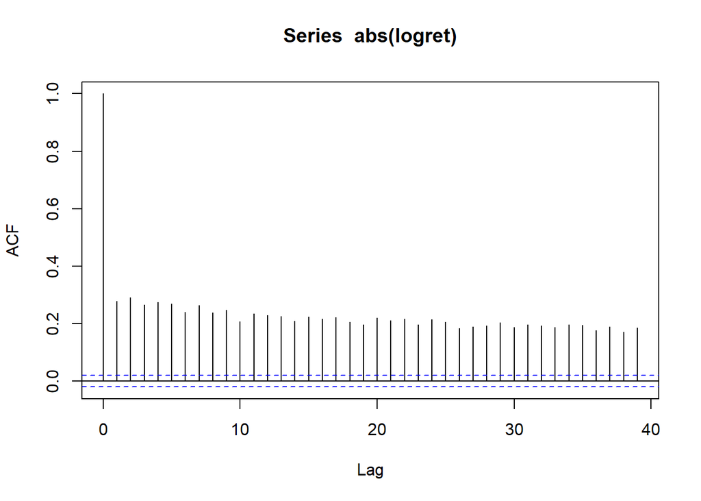

```r
acf(abs(logret))
```

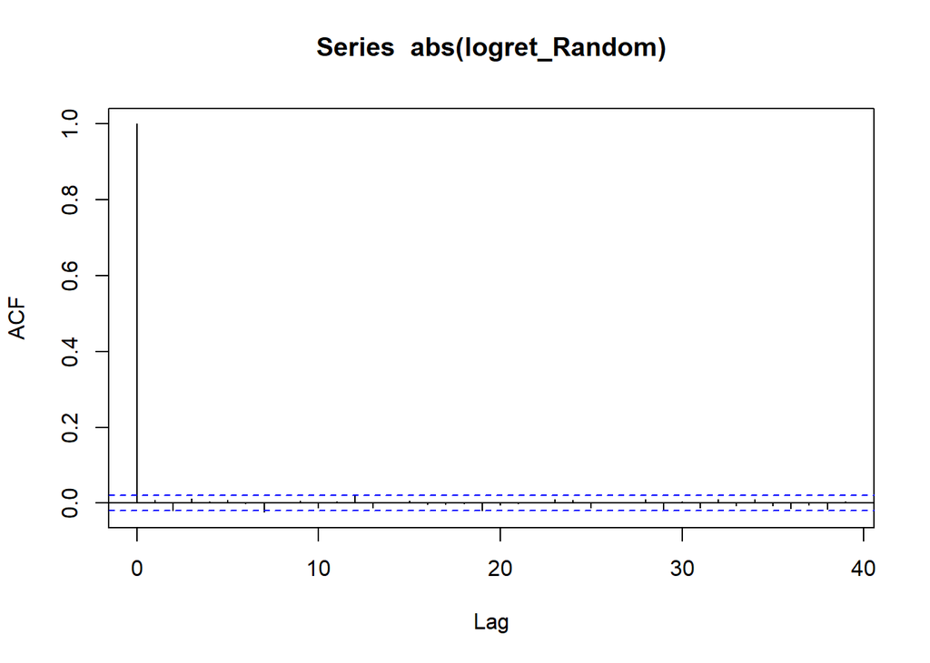

```r
vrec = as.vector(logret)
logret_Random = sample(vrec, length(vrec), replace = FALSE)

acf(abs(logret_Random))
```

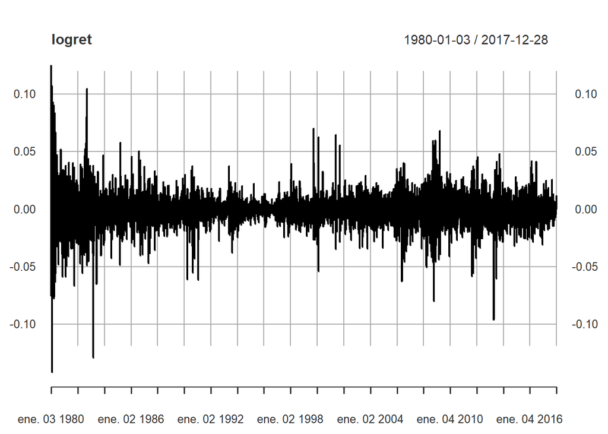

```r
library(ggplot2)

plot(logret)
```

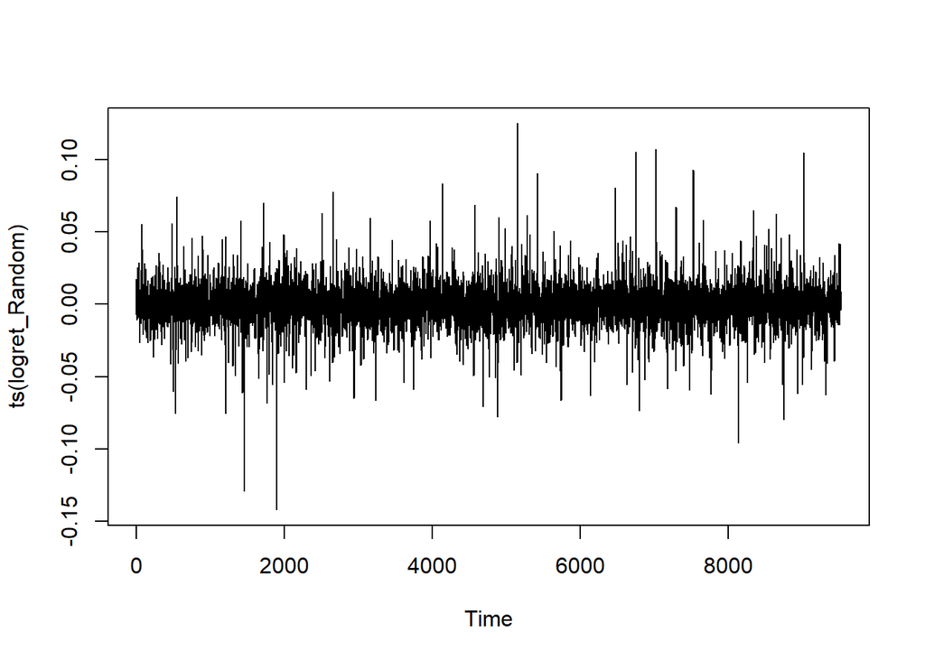

```r
plot(ts(logret_Random))
```

Model with Three equations

La primera ecuación representa en valor del retorno a través del tiempo, $\alpha_0$ que representa el retorno esperado, mientras que $\sqrt{h_t\varepsilon_t}$ representa el retorno no espectado de la serie. $r_t = \alpha_0 + \sqrt{h_t\varepsilon_t}$ (mean equation)

La segunda ecuación representa la varianza que cambia a tra vés del tiempo $h_t = \alpha_0+\beta_1h_{t-1}+\alpha_1\varepsilon^2_{t-1}$ (variance equation) $\varepsilon\sim N(0,1)$ (distribution equation)

Dadala notación anterior, un caso particular está dado por varianza constante ($\beta_1 = 0, \alpha_1=0$), lo que implica que

$r_t = \alpha_0+\sqrt{h_t}\varepsilon_t$ $h_t = \alpha_0$ $\varepsilon_t \sim N(0,1)$

Termina por ser el caso del modelo normal de retornos en logaritmos

$r_t= \mu+\sigma\varepsilon_t, \varepsilon_t \sim N(0,1)$ $\mu= \alpha_, \sigma = \sqrt{\alpha_0}$

Example: $\beta_1 = 0.5, \alpha_1=0.5$

$r_t = \alpha_0 + \sqrt{h_t\varepsilon_t}$ (mean equation) $h_t = \alpha_0+{1/2}*h_{t-1}+{1/2}*\varepsilon^2_{t-1}$

## Estimation rugarch package

```r
library(rugarch)
garch.n <- ugarchspec(variance.model = list(model = "sGARCH", garchOrder = c(1,1)),
                      mean.model = list(armaOrder =c(0,0), include.mean=TRUE),
                      distribution.model = "norm")

fit.garch.n = ugarchfit(spec = garch.n, data = logret)
fit.garch.n
```

```
##
## *---------------------------------*
## *          GARCH Model Fit        *
## *---------------------------------*
##
## Conditional Variance Dynamics
## -----------------------------------
## GARCH Model  : sGARCH(1,1)
## Mean Model   : ARFIMA(0,0,0)
## Distribution : norm
##
## Optimal Parameters
## ------------------------------------
##         Estimate  Std. Error   t value Pr(>|t|)
## mu     -0.000028    0.000082  -0.33746  0.73577
## omega   0.000000    0.000000   2.21866  0.02651
## alpha1  0.060935    0.004088  14.90416  0.00000
## beta1   0.938065    0.003926 238.96601  0.00000
##
## Robust Standard Errors:
##         Estimate  Std. Error  t value Pr(>|t|)
## mu     -0.000028    0.000081 -0.34155  0.73269
## omega   0.000000    0.000002  0.24178  0.80895
## alpha1  0.060935    0.054334  1.12150  0.26208
## beta1   0.938065    0.049560 18.92777  0.00000
##
## LogLikelihood : 30542.15
##
## Information Criteria
## ------------------------------------
##
## Akaike       -6.4109
## Bayes        -6.4079
## Shibata      -6.4109
## Hannan-Quinn -6.4098
##
## Weighted Ljung-Box Test on Standardized Residuals
## ------------------------------------
##                         statistic p-value
## Lag[1]                     0.4098  0.5220
```

[output cut: 37 more lines]

```
## Negative Sign Bias  0.4032 0.6868
## Positive Sign Bias  0.8665 0.3863
## Joint Effect        2.0249 0.5673
##
##
## Adjusted Pearson Goodness-of-Fit Test:
## ------------------------------------
##   group statistic p-value(g-1)
## 1    20     403.7    7.423e-74
## 2    30     453.3    1.049e-77
## 3    40     486.2    1.436e-78
## 4    50     512.5    1.847e-78
##
##
## Elapsed time : 0.4538159
```

```r
save1 = cbind(logret, fit.garch.n@fit$sigma, fit.garch.n@fit$z)
names(save1) = c('logret', 's', 'z')
parml <- fit.garch.n@fit$coef
```

# GARCH(1,1) -t

- Change the distribution equation to a rescaled t distribution
- Here is the GARCH(1,1) -t model: $r_t=\alpha_0+ \sqrt{h_t}\varepsilon_t$ (mean equation) $h_t= \alpha_0+\beta_1h_{t-1}+ \alpha_1\varepsilon^2_{t-1}$ (variance equation) $\varepsilon_t \sim t(v)/\sqrt{\frac{v}{v-2}}$ (distribution model)

## Estimation rugarch package

```r
library(rugarch)
garch.t <- ugarchspec(variance.model = list(model = "sGARCH", garchOrder = c(1,1)),
                      mean.model = list(armaOrder =c(0,0), include.mean=TRUE),
                      distribution.model = "std")

fit.garch.t = ugarchfit(spec = garch.t, data = logret)
fit.garch.t
```

```
##
## *---------------------------------*
## *          GARCH Model Fit        *
## *---------------------------------*
##
## Conditional Variance Dynamics
## -----------------------------------
## GARCH Model  : sGARCH(1,1)
## Mean Model   : ARFIMA(0,0,0)
## Distribution : std
##
## Optimal Parameters
## ------------------------------------
##         Estimate  Std. Error   t value Pr(>|t|)
## mu      0.000020    0.000071   0.28202 0.777929
## omega   0.000000    0.000000   2.25715 0.023999
## alpha1  0.058964    0.002958  19.93080 0.000000
## beta1   0.940034    0.002729 344.42763 0.000000
## shape   4.705505    0.209036  22.51054 0.000000
##
## Robust Standard Errors:
##         Estimate  Std. Error  t value Pr(>|t|)
## mu      0.000020    0.000065  0.30652 0.759207
## omega   0.000000    0.000001  0.67011 0.502787
## alpha1  0.058964    0.021674  2.72054 0.006518
## beta1   0.940034    0.019661 47.81121 0.000000
## shape   4.705505    0.283641 16.58967 0.000000
##
## LogLikelihood : 31116.12
##
## Information Criteria
## ------------------------------------
##
## Akaike       -6.5311
## Bayes        -6.5274
## Shibata      -6.5311
## Hannan-Quinn -6.5299
##
## Weighted Ljung-Box Test on Standardized Residuals
## ------------------------------------
```

[output cut: 40 more lines]

```
## Negative Sign Bias  0.2647 0.7913
## Positive Sign Bias  0.9225 0.3563
## Joint Effect        2.2437 0.5234
##
##
## Adjusted Pearson Goodness-of-Fit Test:
## ------------------------------------
##   group statistic p-value(g-1)
## 1    20     38.23    5.542e-03
## 2    30     58.97    8.293e-04
## 3    40     80.69    9.885e-05
## 4    50     91.35    2.300e-04
##
##
## Elapsed time : 1.194002
```

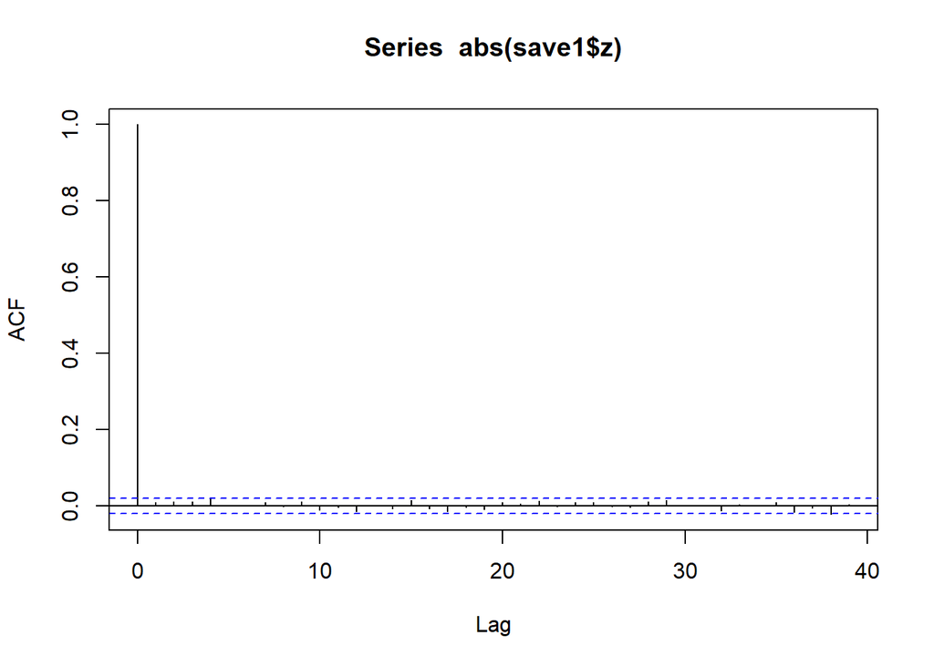

```r
save1 = cbind(logret, fit.garch.t@fit$sigma, fit.garch.t@fit$z)
names(save1) = c('logret', 's', 'z')
acf(abs(save1$z))
```